# Practical R

# Tidyverse

[Tidyverse](https://www.tidyverse.org/) is a collection of R packages that facilitate data manipulation and exploration (cf. [a blog post on not using Tidyverse](https://blog.ephorie.de/why-i-dont-use-the-tidyverse)).

Let’s load tidyverse, and see what packages are included.

```r
library(tidyverse)
```

## core packages

These are select core packages that are included in Tidyverse:  
1. [ggplot2](https://r4ds.had.co.nz/data-visualisation.html) for data visualization  
2. [dplyr](https://dplyr.tidyverse.org/) for data manipulation  
3. [tidyr](https://r4ds.had.co.nz/tidy-data.html) for tidying data  
4. [readr](https://r4ds.had.co.nz/data-import.html) for data import & export  
5. [tibble](https://r4ds.had.co.nz/tibbles.html) for handling data frames  
6. [purrr](https://r4ds.had.co.nz/iteration.html) for iterative programming  
7. [forcats](https://r4ds.had.co.nz/factors.html) for manipulating factors (i.e., categorical variables)

*Note* the packages under `tidyverse_conflicts()`; these are tidyverse functions that have the same names as other functions from different packages (e.g., base R).

Use `package_name::function` to prevent errors from conflicting packages. For example, we can specifically call on `select()` function from `dplyr` package like this:

```r
dplyr::select()
```

## data for excercises

For data manipulation exercises, we will use two example datasets: 1) starwars from `dplyr` package, and

```r
# load a dataset
data(starwars)
```

2. data with participant’s demographic data (i.e., age, sex) and responses to BFI-10 (Rammstedt & John, 2007).

Data codebook here:

| variable name | description | variable name | description |
| --- | --- | --- | --- |
| pid | participant id |  |  |
| age | participant age (in years) |  |  |
| gender | participant gender[^1] | BFI_6 | is outgoing, sociable |
| BFI_1 | is reserved | BFI_7 | tends to find fault with others |
| BFI_2 | is generally trusting | BFI_8 | does a thorough job |
| BFI_3 | tends to be lazy | BFI_9 | gets nervous easily |
| BFI_4 | is relaxed | BFI_10 | has an active imagination |
| BFI_5 | has few artistic interests | BFI_11 | handles stress well |

*Note*. BFI items are scored on 1 - 5 Likert scale; “BFI_1”, “BFI_3”, “BFI_4”, and “BFI_5” are reverse-keyed.

```r
(ocean_data <- readr::read_csv("https://raw.githubusercontent.com/psy218/r_tutorial/master/dataset/example_data.csv"))
```

| pid | age | gender | BFI_1 | BFI_2 | BFI_3 | BFI_4 | BFI_5 | BFI_6 | BFI_7 | BFI_8 | BFI_9 | BFI_10 | BFI_11 |
| --- | --- | --- | --- | --- | --- | --- | --- | --- | --- | --- | --- | --- | --- |
| 1 | 32 | female | 2 | 4 | 3 | 3 | 4 | 2 | 2 | 4 | 3 | 4 | 4 |
| 2 | 31 | female | 2 | 5 | 2 | 1 | 2 | 4 | 2 | 2 | 4 | 5 | 1 |
| 3 | 29 | female | 5 | 1 | 5 | 5 | 5 | 5 | 1 | 5 | 1 | 5 | 5 |
| 4 | 33 | female | 4 | 4 | 4 | 3 | 2 | 4 | 3 | 4 | 3 | 3 | 2 |
| 5 | 29 | male | 3 | 4 | 2 | 1 | 3 | 3 | 2 | 4 | 3 | 3 | 1 |
| 6 | 31 | female | 2 | 5 | 3 | 2 | 3 | 5 | 1 | 4 | 4 | 4 | 2 |
| 7 | 37 | female | 1 | 3 | 4 | 2 | 5 | 1 | 3 | 5 | 4 | 4 | 2 |
| 8 | 35 | female | 2 | 4 | 4 | 2 | 4 | 2 | 2 | 4 | 4 | 2 | 2 |
| 9 | 36 | female | 5 | 1 | 5 | 1 | 5 | 4 | 4 | 5 | 1 | 5 | 1 |
| 10 | 28 | male | 3 | 4 | 3 | 2 | 4 | 3 | 1 | 3 | 2 | 4 | 3 |

[output cut: 310 more lines]

## **piping** (%>%)

Base R and tidyverse R take different approaches to performing multiple functions. Tidyverse R uses a pipe operator (`%>%`), which losely translates to “*then*”

The pipe operator (`%>%`) becomes handy when you…

1. have many interim steps  
   For example, when we want to run a regression with mean-centered variables

```r
starwars %>%
  group_by(gender) %>% # step 1) mean centering height around gender
  mutate(height_mc = height - mean(height, na.rm = T)) %>%
  ungroup() %>%  # ungroup the dataset
  lm(mass ~ height_mc, # step 2) then run a regression model using the mean-centered height
     data = .) %>%
  summary # step 3) see the summary table
```

```
##
## Call:
## lm(formula = mass ~ height_mc, data = .)
##
## Residuals:
##    Min     1Q Median     3Q    Max
##  -59.3  -27.8  -20.4  -16.9 1261.1
##
## Coefficients:
##             Estimate Std. Error t value Pr(>|t|)
## (Intercept)   97.762     22.095    4.42 0.000044 ***
## height_mc      0.579      0.627    0.92     0.36
## ---
## Signif. codes:  0 '***' 0.001 '**' 0.01 '*' 0.05 '.' 0.1 ' ' 1
##
## Residual standard error: 170 on 57 degrees of freedom
##   (28 observations deleted due to missingness)
## Multiple R-squared:  0.0148, Adjusted R-squared:  -0.00252
## F-statistic: 0.854 on 1 and 57 DF,  p-value: 0.359
```

2. do not wish to save the output (e.g., exploratory data analysis)  
   For example, when we want to summarize our data and plot the summary data without saving it.

[figure not shown]

```r
starwars %>%
  # subsetting columns to graph: gender, height, and mass
  select(gender, height:mass) %>%
  pivot_longer(cols = -gender,
               names_to = c("dimension"),
               values_to = "value",
               values_drop_na = T) %>%
  drop_na(gender) %>%
  # plot mean and errorbars around the mean
  ggplot(aes(x = gender,
             y = value,
             fill = dimension)) +
  stat_summary(fun.y = mean,
               geom = "bar",
               position = position_dodge(.8),
               width = .8) +
  stat_summary(fun.data = mean_sdl, # mean +/- constant*sd
               fun.args = list(mult = 1), # constant (1sd)
               geom = "errorbar",
               width = 0.25, position = position_dodge(.8)) +
  xlab("gender of Starwars Character") +
  ylab("Average Measurement") +
  scale_fill_manual("",
                    labels = c("height", "mass"),
                    values = c("#D55E00", "#999999")) +
  theme_bw()
```

As an example, let’s calculate the average height of female Starwars characters.

**Base R**  
In order to perform multiple functions using base R, we perform them sequentially or nest multiple functions.

```r
# sequential operations
female_height_only <- starwars[starwars$gender=="feminine", ]$height # subset data
mean(female_height_only, na.rm = T) # calculate mean of the subset

# nesting subset function inside mean
colMeans(subset(starwars, # subsetting the data frame
                subset = gender == "feminine", # based on the condition
                select = "height"), # column of interest
         na.rm = T) # then perform mean on the subsetted data
```

**tidyverse R**  
tidyverse uses a pipe (`%>%`) to perform multiple functions sequentially without creating an object.

```r
starwars %>% # take the starwars dataset
  subset(subset = gender == "feminine", select = "height") %>% # subset the data
  colMeans(na.rm = T) # calculate the mean
```

### tidy dot

When you use the pipe operator, you can refer to the output from a previous operation with a `.`. For example, when we fit a linear model with a starwars dataset, we can *forward* the dataset straight into the subsequent operation with a `dot` like this:

```r
starwars %>%
  lm(mass ~ height,
     data = .)
```

```
##
## Call:
## lm(formula = mass ~ height, data = .)
##
## Coefficients:
## (Intercept)       height
##     -13.810        0.639
```

## *dplyr* verbs

There are [5 dplyr functions](https://dplyr.tidyverse.org/) that are useful for data manipulation.

| verb | function | example |
| --- | --- | --- |
| `select()` | choose variables by (column) names | `select(starwars, height, mass)` |
| `filter()` | choose observations by (conditional) values | `filter(starwars, gender == "feminine")` |
| `mutate()` | transform or create new variables | `mutate(starwars, BMI = $weight/height^2$)` |
| `summarize()` | summarize variables | `summarize(starwars, mean_height = mean(height, na.rm = T))` |
| `arrange()` | order variables | `arrange(starwars, height, desc(mass))` |

# Data Manipulation

## Subsetting data with `select()` & `filter()`

### `select()` columns

Like the square bracket `data[, "column_name"]`, the dollar sign `data$column_name`, and `subset(data, select = column_name)` function, `select(x)` allows you to extract elements by column name(s).

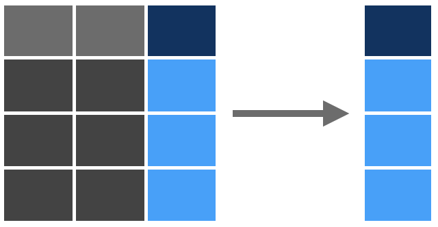

**Base R**

```r
starwars[ ,c("height", "mass")]
```

| height | mass |
| --- | --- |
| 172 | 77.0 |
| 167 | 75.0 |
| 96 | 32.0 |
| 202 | 136.0 |
| 150 | 49.0 |
| 178 | 120.0 |
| 165 | 75.0 |
| 97 | 32.0 |
| 183 | 84.0 |
| 182 | 77.0 |

[output cut: 77 more lines]

**Tidyverse R**

```r
starwars %>%
  select(height, mass)
```

| height | mass |
| --- | --- |
| 172 | 77.0 |
| 167 | 75.0 |
| 96 | 32.0 |
| 202 | 136.0 |
| 150 | 49.0 |
| 178 | 120.0 |
| 165 | 75.0 |
| 97 | 32.0 |
| 183 | 84.0 |
| 182 | 77.0 |

[output cut: 77 more lines]

We can also select *out* a column with a minus sign (i.e., `-`). For example, we can keep all columns but columns from `films` to `starships` like this:

```r
starwars %>%
  select(-c(films:starships))
```

| name | height | mass | hair_color | skin_color | eye_color | birth_year | sex | gender | homeworld | species |
| --- | --- | --- | --- | --- | --- | --- | --- | --- | --- | --- |
| Luke Skywalker | 172 | 77.0 | blond | fair | blue | 19.0 | male | masculine | Tatooine | Human |
| C-3PO | 167 | 75.0 | NA | gold | yellow | 112.0 | none | masculine | Tatooine | Droid |
| R2-D2 | 96 | 32.0 | NA | white, blue | red | 33.0 | none | masculine | Naboo | Droid |
| Darth Vader | 202 | 136.0 | none | white | yellow | 41.9 | male | masculine | Tatooine | Human |
| Leia Organa | 150 | 49.0 | brown | light | brown | 19.0 | female | feminine | Alderaan | Human |
| Owen Lars | 178 | 120.0 | brown, grey | light | blue | 52.0 | male | masculine | Tatooine | Human |
| Beru Whitesun lars | 165 | 75.0 | brown | light | blue | 47.0 | female | feminine | Tatooine | Human |
| R5-D4 | 97 | 32.0 | NA | white, red | red | NA | none | masculine | Tatooine | Droid |
| Biggs Darklighter | 183 | 84.0 | black | light | brown | 24.0 | male | masculine | Tatooine | Human |
| Obi-Wan Kenobi | 182 | 77.0 | auburn, white | fair | blue-gray | 57.0 | male | masculine | Stewjon | Human |

[output cut: 77 more lines]

We can select multiple columns that share a prefix with `num_range()`.  
This is useful when you have multiple items for a scale that start with the same prefix. For example, if you have 10 items for BFI measure that follow the same naming pattern of BFI_number (e.g., BFI_1, BFI_2), you can provide the prefix followed by the item numbers: `num_range("BFI_", 1:10)`

```r
ocean_data %>%
  select(num_range("BFI_", 1:10))
```

| BFI_1 | BFI_2 | BFI_3 | BFI_4 | BFI_5 | BFI_6 | BFI_7 | BFI_8 | BFI_9 | BFI_10 |
| --- | --- | --- | --- | --- | --- | --- | --- | --- | --- |
| 2 | 4 | 3 | 3 | 4 | 2 | 2 | 4 | 3 | 4 |
| 2 | 5 | 2 | 1 | 2 | 4 | 2 | 2 | 4 | 5 |
| 5 | 1 | 5 | 5 | 5 | 5 | 1 | 5 | 1 | 5 |
| 4 | 4 | 4 | 3 | 2 | 4 | 3 | 4 | 3 | 3 |
| 3 | 4 | 2 | 1 | 3 | 3 | 2 | 4 | 3 | 3 |
| 2 | 5 | 3 | 2 | 3 | 5 | 1 | 4 | 4 | 4 |
| 1 | 3 | 4 | 2 | 5 | 1 | 3 | 5 | 4 | 4 |
| 2 | 4 | 4 | 2 | 4 | 2 | 2 | 4 | 4 | 2 |
| 5 | 1 | 5 | 1 | 5 | 4 | 4 | 5 | 1 | 5 |
| 3 | 4 | 3 | 2 | 4 | 3 | 1 | 3 | 2 | 4 |

[output cut: 310 more lines]

#### conditional selection

You can combine `select()` function with conditional statements, such as `starts_with()`.

These are some useful conditional statements you can use with `select()`:

| condition | function |
| --- | --- |
| `starts_with("x")` | column names that begin with “x” |
| `ends_with("x")` | column names that end with “x” |
| `contains("x")` | column names that contain “x” |
| `num_range("x", 1:3)` | columns that match `x1`, `x2`, and `x3` |
| `everything()` | select all columns; useful for rearranging |
| `one_of(c("height", "mass"))` | select one of `height` or `mass` |

For example, if we want to find all the columns whose names begin with the letter *h*, we can nest the conditional statement, `starts_with("h")` inside the `select()` function.

```r
starwars %>%
  select(starts_with("h"))
```

| height | hair_color | homeworld |
| --- | --- | --- |
| 172 | blond | Tatooine |
| 167 | NA | Tatooine |
| 96 | NA | Naboo |
| 202 | none | Tatooine |
| 150 | brown | Alderaan |
| 178 | brown, grey | Tatooine |
| 165 | brown | Tatooine |
| 97 | NA | Tatooine |
| 183 | black | Tatooine |
| 182 | auburn, white | Stewjon |

[output cut: 77 more lines]

#### renaming with `select()`

You can rename column names by providing a new name followed by an equal sign and the original name inside the select function: `select(new_name = original_name)`.

```r
# renaming `films` to `movie` and reorganize columns such that name and species come before all other columns
starwars %>%
  select(name, species, # columns to be placed first
         movie = films, # renaming films to movie
         everything())  # reorganizing columns
```

| name | species | movie | height | mass | hair_color | skin_color | eye_color | birth_year | sex | gender | homeworld | vehicles | starships |
| --- | --- | --- | --- | --- | --- | --- | --- | --- | --- | --- | --- | --- | --- |
| Luke Skywalker | Human |  | 172 | 77.0 | blond | fair | blue | 19.0 | male | masculine | Tatooine |  |  |
| C-3PO | Droid |  | 167 | 75.0 | NA | gold | yellow | 112.0 | none | masculine | Tatooine |  |  |
| R2-D2 | Droid |  | 96 | 32.0 | NA | white, blue | red | 33.0 | none | masculine | Naboo |  |  |
| Darth Vader | Human |  | 202 | 136.0 | none | white | yellow | 41.9 | male | masculine | Tatooine |  |  |
| Leia Organa | Human |  | 150 | 49.0 | brown | light | brown | 19.0 | female | feminine | Alderaan |  |  |
| Owen Lars | Human |  | 178 | 120.0 | brown, grey | light | blue | 52.0 | male | masculine | Tatooine |  |  |
| Beru Whitesun lars | Human |  | 165 | 75.0 | brown | light | blue | 47.0 | female | feminine | Tatooine |  |  |
| R5-D4 | Droid |  | 97 | 32.0 | NA | white, red | red | NA | none | masculine | Tatooine |  |  |
| Biggs Darklighter | Human |  | 183 | 84.0 | black | light | brown | 24.0 | male | masculine | Tatooine |  |  |
| Obi-Wan Kenobi | Human |  | 182 | 77.0 | auburn, white | fair | blue-gray | 57.0 | male | masculine | Stewjon |  |  |

[output cut: 77 more lines]

### `filter()` observations

Like the conditional statement inside a square bracket `[]`, `filter()` allows you to extract elements that meet specified conditions.

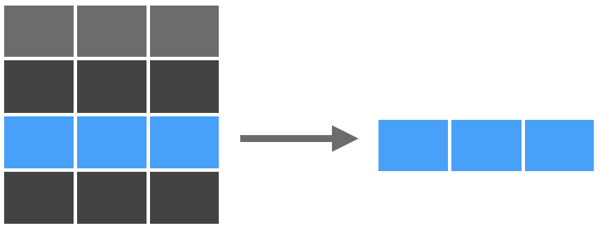

For example, we can retain data from starwars characters whose height is greater than 100 by providing the conditional statement (`height > 100`) in `filter()`:

```r
starwars %>%
  filter(height > 100)
```

| name | height | mass | hair_color | skin_color | eye_color | birth_year | sex | gender | homeworld | species | films | vehicles | starships |
| --- | --- | --- | --- | --- | --- | --- | --- | --- | --- | --- | --- | --- | --- |
| Luke Skywalker | 172 | 77.0 | blond | fair | blue | 19.0 | male | masculine | Tatooine | Human |  |  |  |
| C-3PO | 167 | 75.0 | NA | gold | yellow | 112.0 | none | masculine | Tatooine | Droid |  |  |  |
| Darth Vader | 202 | 136.0 | none | white | yellow | 41.9 | male | masculine | Tatooine | Human |  |  |  |
| Leia Organa | 150 | 49.0 | brown | light | brown | 19.0 | female | feminine | Alderaan | Human |  |  |  |
| Owen Lars | 178 | 120.0 | brown, grey | light | blue | 52.0 | male | masculine | Tatooine | Human |  |  |  |
| Beru Whitesun lars | 165 | 75.0 | brown | light | blue | 47.0 | female | feminine | Tatooine | Human |  |  |  |
| Biggs Darklighter | 183 | 84.0 | black | light | brown | 24.0 | male | masculine | Tatooine | Human |  |  |  |
| Obi-Wan Kenobi | 182 | 77.0 | auburn, white | fair | blue-gray | 57.0 | male | masculine | Stewjon | Human |  |  |  |
| Anakin Skywalker | 188 | 84.0 | blond | fair | blue | 41.9 | male | masculine | Tatooine | Human |  |  |  |
| Wilhuff Tarkin | 180 | NA | auburn, grey | fair | blue | 64.0 | male | masculine | Eriadu | Human |  |  |  |

[output cut: 64 more lines]

**Base R**

```r
starwars[c(starwars$mass<1000 & starwars$height > 100), ]
```

| name | height | mass | hair_color | skin_color | eye_color | birth_year | sex | gender | homeworld | species | films | vehicles | starships |
| --- | --- | --- | --- | --- | --- | --- | --- | --- | --- | --- | --- | --- | --- |
| Luke Skywalker | 172 | 77.0 | blond | fair | blue | 19.0 | male | masculine | Tatooine | Human |  |  |  |
| C-3PO | 167 | 75.0 | NA | gold | yellow | 112.0 | none | masculine | Tatooine | Droid |  |  |  |
| Darth Vader | 202 | 136.0 | none | white | yellow | 41.9 | male | masculine | Tatooine | Human |  |  |  |
| Leia Organa | 150 | 49.0 | brown | light | brown | 19.0 | female | feminine | Alderaan | Human |  |  |  |
| Owen Lars | 178 | 120.0 | brown, grey | light | blue | 52.0 | male | masculine | Tatooine | Human |  |  |  |
| Beru Whitesun lars | 165 | 75.0 | brown | light | blue | 47.0 | female | feminine | Tatooine | Human |  |  |  |
| Biggs Darklighter | 183 | 84.0 | black | light | brown | 24.0 | male | masculine | Tatooine | Human |  |  |  |
| Obi-Wan Kenobi | 182 | 77.0 | auburn, white | fair | blue-gray | 57.0 | male | masculine | Stewjon | Human |  |  |  |
| Anakin Skywalker | 188 | 84.0 | blond | fair | blue | 41.9 | male | masculine | Tatooine | Human |  |  |  |
| NA | NA | NA | NA | NA | NA | NA | NA | NA | NA | NA |  |  |  |

[output cut: 69 more lines]

**tidyverse R**

```r
starwars %>%
  filter(mass < 1000, height > 100)
```

| name | height | mass | hair_color | skin_color | eye_color | birth_year | sex | gender | homeworld | species | films | vehicles | starships |
| --- | --- | --- | --- | --- | --- | --- | --- | --- | --- | --- | --- | --- | --- |
| Luke Skywalker | 172 | 77.0 | blond | fair | blue | 19.0 | male | masculine | Tatooine | Human |  |  |  |
| C-3PO | 167 | 75.0 | NA | gold | yellow | 112.0 | none | masculine | Tatooine | Droid |  |  |  |
| Darth Vader | 202 | 136.0 | none | white | yellow | 41.9 | male | masculine | Tatooine | Human |  |  |  |
| Leia Organa | 150 | 49.0 | brown | light | brown | 19.0 | female | feminine | Alderaan | Human |  |  |  |
| Owen Lars | 178 | 120.0 | brown, grey | light | blue | 52.0 | male | masculine | Tatooine | Human |  |  |  |
| Beru Whitesun lars | 165 | 75.0 | brown | light | blue | 47.0 | female | feminine | Tatooine | Human |  |  |  |
| Biggs Darklighter | 183 | 84.0 | black | light | brown | 24.0 | male | masculine | Tatooine | Human |  |  |  |
| Obi-Wan Kenobi | 182 | 77.0 | auburn, white | fair | blue-gray | 57.0 | male | masculine | Stewjon | Human |  |  |  |
| Anakin Skywalker | 188 | 84.0 | blond | fair | blue | 41.9 | male | masculine | Tatooine | Human |  |  |  |
| Chewbacca | 228 | 112.0 | brown | unknown | blue | 200.0 | male | masculine | Kashyyyk | Wookiee |  |  |  |

[output cut: 42 more lines]

#### conditional filtering

Like `select()`, you can add more specification inside the `filter()` function with logical operators (e.g., `==`), and `between()` or `is.na()` statements.

an exclamanation mark before a function negates it; `!function()`

### **Exercise 1**

Let’s subset our starwars data set using multiple conditions.

#### Question

Find the names (`name`) and gender (`gender`) of human characters (i.e., `species == Human`) who are between 23 to 35 years of age (i.e., `birth_year`)and do not have blue eyes (i.e., `eye_colour`).

#### Answer

```r
starwars %>%
  filter(species == "Human", # human
         eye_color != "blue", # eye color not blue
         between(birth_year, left = 23, right = 35)) %>% # age falling between 23 and 35
  select(name, gender) # just choosing the name column
```

| name | gender |
| --- | --- |
| Biggs Darklighter | masculine |
| Han Solo | masculine |
| Boba Fett | masculine |
| Lando Calrissian | masculine |

## Summarize data with `mutate()` and `summarize()`

### `mutate()` variables

`mutate()` creates a new variable (or an existing variable) by operating on our dataset.

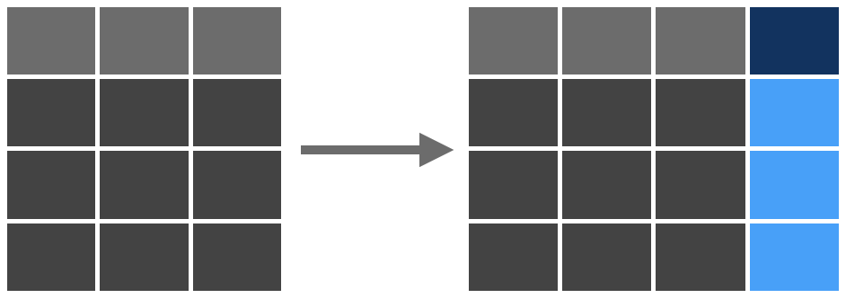

We do so by providing a name of a new (or existing) column name followed by an equal sign and operations: `mutate(column_name = operation(old_column))`. Operations can be a simple arithmatic (e.g., adding two columns together), or a function (e.g., averaging multiple columns with `mean()` function).

**Base R**

```r
# using `within()`
within(starwars,
       {bmi = 703 * mass/(height^2)})

# Or, writing directly inside
starwars$bmi = 703 * starwars$mass/(starwars$height^2)
```

**tidyverse R**

```r
starwars %>%
  mutate(bmi = 703 * mass/(height^2)) %>%
  select(name, height, mass, bmi)
```

| name | height | mass | bmi |
| --- | --- | --- | --- |
| Luke Skywalker | 172 | 77.0 | 1.830 |
| C-3PO | 167 | 75.0 | 1.891 |
| R2-D2 | 96 | 32.0 | 2.441 |
| Darth Vader | 202 | 136.0 | 2.343 |
| Leia Organa | 150 | 49.0 | 1.531 |
| Owen Lars | 178 | 120.0 | 2.663 |
| Beru Whitesun lars | 165 | 75.0 | 1.937 |
| R5-D4 | 97 | 32.0 | 2.391 |
| Biggs Darklighter | 183 | 84.0 | 1.763 |
| Obi-Wan Kenobi | 182 | 77.0 | 1.634 |

[output cut: 77 more lines]

These are some functions you can use with `mutate()`:

1. Conditionally operate on a column with `ifelse()`

   run `?ifelse()`, or check Ex 5 in the Basic R tutorial for `ifelse()` function

```r
starwars %>%
  mutate(skin_color = ifelse(skin_color == "pale",
                             yes = "ghostly",
                             no = skin_color))
```

| name | height | mass | hair_color | skin_color | eye_color | birth_year | sex | gender | homeworld | species | films | vehicles | starships |
| --- | --- | --- | --- | --- | --- | --- | --- | --- | --- | --- | --- | --- | --- |
| Luke Skywalker | 172 | 77.0 | blond | fair | blue | 19.0 | male | masculine | Tatooine | Human |  |  |  |
| C-3PO | 167 | 75.0 | NA | gold | yellow | 112.0 | none | masculine | Tatooine | Droid |  |  |  |
| R2-D2 | 96 | 32.0 | NA | white, blue | red | 33.0 | none | masculine | Naboo | Droid |  |  |  |
| Darth Vader | 202 | 136.0 | none | white | yellow | 41.9 | male | masculine | Tatooine | Human |  |  |  |
| Leia Organa | 150 | 49.0 | brown | light | brown | 19.0 | female | feminine | Alderaan | Human |  |  |  |
| Owen Lars | 178 | 120.0 | brown, grey | light | blue | 52.0 | male | masculine | Tatooine | Human |  |  |  |
| Beru Whitesun lars | 165 | 75.0 | brown | light | blue | 47.0 | female | feminine | Tatooine | Human |  |  |  |
| R5-D4 | 97 | 32.0 | NA | white, red | red | NA | none | masculine | Tatooine | Droid |  |  |  |
| Biggs Darklighter | 183 | 84.0 | black | light | brown | 24.0 | male | masculine | Tatooine | Human |  |  |  |
| Obi-Wan Kenobi | 182 | 77.0 | auburn, white | fair | blue-gray | 57.0 | male | masculine | Stewjon | Human |  |  |  |

[output cut: 77 more lines]

This is useful for recoding variables; e.g., dummy-coding or assigning numerical values to a categorical variable.

```r
# recode `gender` by creating a new variable, `women` to represent dummy-coded women
ocean_data %>%
  mutate(women = ifelse(gender == "female",
                        yes = 0, # assigning `0` to women
                        no = ifelse(gender == "male",
                                    yes = 1, # assinging `1` to men
                                    gender))) %>%  # every other variables (e.g., NA) will remain the same
  # check the dummy-coded women variable
  select(pid, gender, women)
```

| pid | gender | women |
| --- | --- | --- |
| 1 | female | 0 |
| 2 | female | 0 |
| 3 | female | 0 |
| 4 | female | 0 |
| 5 | male | 1 |
| 6 | female | 0 |
| 7 | female | 0 |
| 8 | female | 0 |
| 9 | female | 0 |
| 10 | male | 1 |

[output cut: 310 more lines]

2. Code a certain value as missing (i.e., `NA`) with `na_if()` by providing the column name followed by the value that should be coded as missing (e.g., -99): `na_if(column_name, -99)`

```r
starwars %>%
  select(name, eye_color) %>%
  mutate(eye_color = na_if(eye_color, # column to recode
                           "unknown")) # value to be converted to a missing value
```

| name | eye_color |
| --- | --- |
| Luke Skywalker | blue |
| C-3PO | yellow |
| R2-D2 | red |
| Darth Vader | yellow |
| Leia Organa | brown |
| Owen Lars | blue |
| Beru Whitesun lars | blue |
| R5-D4 | red |
| Biggs Darklighter | brown |
| Obi-Wan Kenobi | blue-gray |

[output cut: 77 more lines]

#### conditional mutation

**mutate_at()**  
We can conditionally mutate our datasets based on variable names (`mutate_at()`) and/or specific conditions (`mutate_if()`).

`mutate_at()` takes two additional arguments:  
1) names of the column(s) you want to mutate (`.vars`), and  
2) function(s) to mutate with (`.funs`):

```r
data %>%
  mutate_at(.vars = c("column_name1", "column_name2", "column_name3"), # column names
            .funs = list(min, max, mean, sd), # multiple functions to be applied on those columns
            na.rm = TRUE) # specification for the functions above; removing missing values
```

You can also combine conditional select() statements inside `mutate_at()`, nested in `vars()`.

```r
# `starts_with()`
data %>%
  mutate_at(vars(starts_with("BFI_")), ~function(.))
```

**mutate_if()**  
`mutate_if()` requires a conditional statement (`.predicate`), instead of variable names.

```
data %>%
  mutate_if(.predicate = conditional_statement,
            .funs = list(min, max))
```

The conditional statements can be a type of variables (e.g., `is.numeric`; `is.double`; `is.character`), which is useful for iterating through columns of the same type.

For example, you may have to convert varialbes that are numeric to whole numbers. You can do this with `mutate_if()`:

```r
starwars %>%
  mutate_if(is.double, # if a variable is double (numeric)
            as.integer) # convert it to whole numbers
```

##### item-scoring with `mutate_at()`

`mutate_at()` is useufl for scoring measures with multiple items saved across columns.

Let’s reverse score BFI items 1, 3, 4, and 5, and create aggregate scores of OCEAN.

Step 1: Selectively reverse score items that are reverse-keyed: BFI_1, 3:5

```r
ocean_data %>%
  mutate_at(c("BFI_1", "BFI_3", "BFI_4", "BFI_5"), # select reverse-keyed items
            # vars(num_range("BFI_", c(1, 3:5))),
            ~(6 - .)) # reverse-score the selected columns (as indicated by the tidy dot)
```

| pid | age | gender | BFI_1 | BFI_2 | BFI_3 | BFI_4 | BFI_5 | BFI_6 | BFI_7 | BFI_8 | BFI_9 | BFI_10 | BFI_11 |
| --- | --- | --- | --- | --- | --- | --- | --- | --- | --- | --- | --- | --- | --- |
| 1 | 32 | female | 4 | 4 | 3 | 3 | 2 | 2 | 2 | 4 | 3 | 4 | 4 |
| 2 | 31 | female | 4 | 5 | 4 | 5 | 4 | 4 | 2 | 2 | 4 | 5 | 1 |
| 3 | 29 | female | 1 | 1 | 1 | 1 | 1 | 5 | 1 | 5 | 1 | 5 | 5 |
| 4 | 33 | female | 2 | 4 | 2 | 3 | 4 | 4 | 3 | 4 | 3 | 3 | 2 |
| 5 | 29 | male | 3 | 4 | 4 | 5 | 3 | 3 | 2 | 4 | 3 | 3 | 1 |
| 6 | 31 | female | 4 | 5 | 3 | 4 | 3 | 5 | 1 | 4 | 4 | 4 | 2 |
| 7 | 37 | female | 5 | 3 | 2 | 4 | 1 | 1 | 3 | 5 | 4 | 4 | 2 |
| 8 | 35 | female | 4 | 4 | 2 | 4 | 2 | 2 | 2 | 4 | 4 | 2 | 2 |
| 9 | 36 | female | 1 | 1 | 1 | 5 | 1 | 4 | 4 | 5 | 1 | 5 | 1 |
| 10 | 28 | male | 3 | 4 | 3 | 4 | 2 | 3 | 1 | 3 | 2 | 4 | 3 |

[output cut: 310 more lines]

Step 2: Reverse score items (without saving) and calculate an aggregate score

```r
ocean_data %>%
  # reverse code items first
  mutate_at(vars(num_range("BFI_", c(1, 3:5))),
            ~(6 - .)) %>%
  # then create a new variable to store aggregate scores
  mutate(extraversion = rowMeans(cbind(BFI_1, BFI_6), na.rm = T),
         conscientiousness = rowMeans(cbind(BFI_3, BFI_8), na.rm = T),
         neuroticism = rowMeans(cbind(BFI_4, BFI_9, BFI_11), na.rm = T),
         agreableness = rowMeans(cbind(BFI_2, BFI_7), na.rm = T),
         openness = rowMeans(cbind(BFI_5, BFI_10), na.rm = T),
         .after = gender) # place them after gender
```

| pid | age | gender | extraversion | conscientiousness | neuroticism | agreableness | openness | BFI_1 | BFI_2 | BFI_3 | BFI_4 | BFI_5 | BFI_6 | BFI_7 | BFI_8 | BFI_9 | BFI_10 | BFI_11 |
| --- | --- | --- | --- | --- | --- | --- | --- | --- | --- | --- | --- | --- | --- | --- | --- | --- | --- | --- |
| 1 | 32 | female | 3.0 | 3.5 | 3.33 | 3.0 | 3.0 | 4 | 4 | 3 | 3 | 2 | 2 | 2 | 4 | 3 | 4 | 4 |
| 2 | 31 | female | 4.0 | 3.0 | 3.33 | 3.5 | 4.5 | 4 | 5 | 4 | 5 | 4 | 4 | 2 | 2 | 4 | 5 | 1 |
| 3 | 29 | female | 3.0 | 3.0 | 2.33 | 1.0 | 3.0 | 1 | 1 | 1 | 1 | 1 | 5 | 1 | 5 | 1 | 5 | 5 |
| 4 | 33 | female | 3.0 | 3.0 | 2.67 | 3.5 | 3.5 | 2 | 4 | 2 | 3 | 4 | 4 | 3 | 4 | 3 | 3 | 2 |
| 5 | 29 | male | 3.0 | 4.0 | 3.00 | 3.0 | 3.0 | 3 | 4 | 4 | 5 | 3 | 3 | 2 | 4 | 3 | 3 | 1 |
| 6 | 31 | female | 4.5 | 3.5 | 3.33 | 3.0 | 3.5 | 4 | 5 | 3 | 4 | 3 | 5 | 1 | 4 | 4 | 4 | 2 |
| 7 | 37 | female | 3.0 | 3.5 | 3.33 | 3.0 | 2.5 | 5 | 3 | 2 | 4 | 1 | 1 | 3 | 5 | 4 | 4 | 2 |
| 8 | 35 | female | 3.0 | 3.0 | 3.33 | 3.0 | 2.0 | 4 | 4 | 2 | 4 | 2 | 2 | 2 | 4 | 4 | 2 | 2 |
| 9 | 36 | female | 2.5 | 3.0 | 2.33 | 2.5 | 3.0 | 1 | 1 | 1 | 5 | 1 | 4 | 4 | 5 | 1 | 5 | 1 |
| 10 | 28 | male | 3.0 | 3.0 | 3.00 | 2.5 | 3.0 | 3 | 4 | 3 | 4 | 2 | 3 | 1 | 3 | 2 | 4 | 3 |

[output cut: 310 more lines]

### `summarize()` data

Without creating a new variable with `mutate()`, we can create a summary of our data using `summarize()` function with a similar formula: `variable_name = operation(column_name)`.

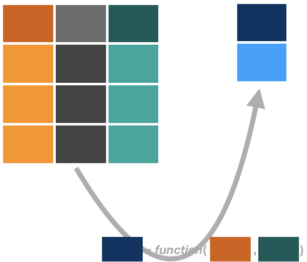

For example, let’s look at average `height` and `mass` with their standard deviations using `mean()` and `sd()` functions.

```r
starwars %>%
  summarize(height_mean = mean(height, na.rm = T),
            height_sd = sd(height, na.rm = T),
            mass_mean = mean(mass, na.rm = T),
            mass_sd = sd(mass, na.rm = T))
```

| height_mean | height_sd | mass_mean | mass_sd |
| --- | --- | --- | --- |
| 174 | 34.8 | 97.3 | 169 |

```r
# alternatively, you can use `summarize_at()` if you are feeling terse
starwars %>%
  summarise_at(vars(height, mass), # variables we want to apply functions on
               list(~mean(., na.rm = T), # first function
                    ~sd(., na.rm = T))) # second function
```

| height_mean | mass_mean | height_sd | mass_sd |
| --- | --- | --- | --- |
| 174 | 97.3 | 34.8 | 169 |

#### summary functions

You can use the following functions with `summary()`.

| name | function |
| --- | --- |
| `n()` | # of observations or row |
| `n_distinct()` | # of *unique* observations or a given column |
| `mean(x)` | average of x |
| `sd(x)` | standard deviation of x |
| `min(x)` | minimum value of x |
| `max(x)` | maximum value of x |
| `sum(is.na(x))` | # of missing observations |

```r
starwars %>%
  summarize(height_n = n(),
            unique_gender = n_distinct(gender),
            height_mean = mean(height, na.rm = T),
            height_sd = sd(height, na.rm = T),
            height_min = min(height, na.rm = T),
            height_max = max(height, na.rm = T),
            height_na = sum(is.na(height)))
```

| height_n | unique_gender | height_mean | height_sd | height_min | height_max | height_na |
| --- | --- | --- | --- | --- | --- | --- |
| 87 | 3 | 174 | 34.8 | 66 | 264 | 6 |

Check for more useful summary functions with `?summarize()`

#### selective summary

Like conditional mutatation, `summarize()` function can be applied selective at specific variables (`summarize_at()`) or variables of a specific type (`summarize_if()`).

You can selectively apply the same functions to multiple variables using `summarize_at()`:

```r
starwars %>%
  summarize_at(.vars = vars("height", "mass"), # specify which variables
               .funs = list(~mean(., na.rm = T), # list of functions you want to apply
                    ~sd(., na.rm = T),
                    ~min(., na.rm = T),
                    ~max(., na.rm = T),
                    ~sum(is.na(.)))) %>%
  pivot_longer(cols = everything(), # (optional) to make the summary table easier to read
               names_to = c(".value", "test"),
               names_sep = "_")
```

| test | height | mass |
| --- | --- | --- |
| mean | 174.4 | 97.3 |
| sd | 34.8 | 169.5 |
| min | 66.0 | 15.0 |
| max | 264.0 | 1358.0 |
| sum | 6.0 | 28.0 |

`summarize_if()` is useful for data inspection of similar variable types (e.g., numeric/double):

```r
starwars %>%
  summarise_if(is.numeric, # the type of variable that makes sense to compute descriptive stats.
               list(mean = mean, sd = sd, # functions for the descriptive stats: mean, sd, & range
                    min = min, max = max),
               na.rm = T) %>% # additional specification for those functions: removing missing values
  # (optional) organization to make the table easier to read
  pivot_longer(cols = everything(),
               names_to = c(".value", "test"),
               names_pattern = "(.*)_(mean|sd|min|max)")
```

| test | height | mass | birth_year |
| --- | --- | --- | --- |
| mean | 174.4 | 97.3 | 87.6 |
| sd | 34.8 | 169.5 | 154.7 |
| min | 66.0 | 15.0 | 8.0 |
| max | 264.0 | 1358.0 | 896.0 |

### conditional manipulation with `group_by()`

When we want to mutate or create a summary for different groups (e.g., gender), we can combine `mutate()` and `summarize()` with `group_by()` function.

We provide a dataset, then provide a grouping variable inside `group_by()` (e.g., “gender”; `group_by(gender)`) to divide the dataset based on the grouping variable (i.e., gender), and mutate or summarize separately for these groups.

For example, we can calculate average height and mass for each gender group.

```r
starwars %>%
  group_by(gender) %>% # grouping our data based on gender
  summarise_at(c("height", "mass"),
               list(mean = mean, sd = sd),
               na.rm = TRUE)
```

| gender | height_mean | mass_mean | height_sd | mass_sd |
| --- | --- | --- | --- | --- |
| feminine | 165 | 54.7 | 23.55 | 8.59 |
| masculine | 177 | 106.1 | 37.65 | 184.97 |
| NA | 181 | 48.0 | 2.89 | NA |

`group_by()` is also useful when we want to mean-centre variables.

```r
ocean_data %>%
  # this is just another way of computing aggregate scores; see item-scoring under `mutate_at()`
  rowwise() %>% # tell R to do this for every row
  mutate(BFI_1 = 6 - BFI_1, # reverse score BFI_1
         extraversion = mean(c_across(c("BFI_1", "BFI_6")))) %>% # create an extraversion score
  group_by(gender) %>%  # group data by gender
  mutate(extraversion_gm = mean(extraversion, na.rm = T), # mean extraversion for women and men
         # subtract individual extraversion score from average extraversion of women and men
         extraversion_gmc = extraversion - extraversion_gm,
         .after = extraversion) %>%  # where we want these columns to appear
  # ungroup() data so the subsequent operations won't be applied separately to different groups
  ungroup()
```

| pid | age | gender | BFI_1 | BFI_2 | BFI_3 | BFI_4 | BFI_5 | BFI_6 | BFI_7 | BFI_8 | BFI_9 | BFI_10 | BFI_11 | extraversion | extraversion_gm | extraversion_gmc |
| --- | --- | --- | --- | --- | --- | --- | --- | --- | --- | --- | --- | --- | --- | --- | --- | --- |
| 1 | 32 | female | 4 | 4 | 3 | 3 | 4 | 2 | 2 | 4 | 3 | 4 | 4 | 3.0 | 3.37 | -0.3697 |
| 2 | 31 | female | 4 | 5 | 2 | 1 | 2 | 4 | 2 | 2 | 4 | 5 | 1 | 4.0 | 3.37 | 0.6303 |
| 3 | 29 | female | 1 | 1 | 5 | 5 | 5 | 5 | 1 | 5 | 1 | 5 | 5 | 3.0 | 3.37 | -0.3697 |
| 4 | 33 | female | 2 | 4 | 4 | 3 | 2 | 4 | 3 | 4 | 3 | 3 | 2 | 3.0 | 3.37 | -0.3697 |
| 5 | 29 | male | 3 | 4 | 2 | 1 | 3 | 3 | 2 | 4 | 3 | 3 | 1 | 3.0 | 3.41 | -0.4065 |
| 6 | 31 | female | 4 | 5 | 3 | 2 | 3 | 5 | 1 | 4 | 4 | 4 | 2 | 4.5 | 3.37 | 1.1303 |
| 7 | 37 | female | 5 | 3 | 4 | 2 | 5 | 1 | 3 | 5 | 4 | 4 | 2 | 3.0 | 3.37 | -0.3697 |
| 8 | 35 | female | 4 | 4 | 4 | 2 | 4 | 2 | 2 | 4 | 4 | 2 | 2 | 3.0 | 3.37 | -0.3697 |
| 9 | 36 | female | 1 | 1 | 5 | 1 | 5 | 4 | 4 | 5 | 1 | 5 | 1 | 2.5 | 3.37 | -0.8697 |
| 10 | 28 | male | 3 | 4 | 3 | 2 | 4 | 3 | 1 | 3 | 2 | 4 | 3 | 3.0 | 3.41 | -0.4065 |

[output cut: 310 more lines]

#### **Exercise 2**

##### Answer

```r
#' step 1: creating a custom function to reverse-score items
reverse_x <- function(x, max) {
  ifelse(is.na(x) == FALSE, (max + 1) - x , NA)
}

#' step 2: reverse score, create an average score, and centre it on group mean
#' @param neuroticism aggregate score of neuroticism (BFI_4, BFI_11, BFI_9)
#' @param neuroticism_mc mean-centered neuroticism

ocean_data <- ocean_data %>%
  mutate_at( vars(c("BFI_4", "BFI_11")), # specify which variables to apply the function
             ~reverse_x(., max = 5)) %>% # apply the reverse-score function
  mutate(neuroticism = rowMeans(cbind(BFI_4, BFI_11, BFI_9), na.rm = T)) %>%  # create an aggregate score
  group_by(gender) %>% # this will allow us to calcualte the group mean when we use mean function
  mutate(neuroticism_mc = neuroticism - mean(neuroticism, na.rm = T)) # center neuroticism score on group mean
```

[^1]: Please note that the data incorrectly uses sex labels (“female” and “male”) for `gender`; I retained the original column name as the data is not mine.